# Transposer une table

JLL

16 octobre 2018

# Transposer

## Problématique : PROC TRANSPOSE

En général un “data frame” R est similaire - au moins en apparence - à une table SAS : c’est un ensemble d’observations (en R les lignes) pour lesquelles on dispose d’un ensemble de mesures, les variables (en R les colonnes). Néanmoins, cette distinction entre observations et variables peut parfois s’effacer.

Par exemple si on dispose des populations d’un nombre fixe de communes à différentes dates, on peut considérer que l’observation c’est la commune et que les variables contiennent les données pour les différentes dates : c’est le point de vue des bases de données géographiques.

```
##   Commune  2015  2010  2006
## 1   16015 42081 41613 42096
## 2   17300 75404 75170 77196
## 3   79191 58952 57325 58066
## 4   86194 87918 87697 88776
```

### Transposition totale

Mais on peut aussi se placer du point de vue de la collecte : à chaque date on a observé un certain nombre de communes. A chaque date de collecte correspond alors un ensemble de variables contenantt les données pour les différentes communes.

```
##   Date 16015 17300 79191 86194
## 1 2015 42081 75404 58952 87918
## 2 2010 41613 75170 57325 87697
## 3 2006 42096 77196 58066 88776
```

### Mise en format pivot (format “long”)

On peut enfin considérer que les identifiants de lignes et de colonnes sont en fait les deux coordonnées qui permettent d’accéder à une donnée dans un espace à deux dimensions. Ce format (coordonnées, valeur) est parfois requis pour faire certains traitements sous tableur ou pour échanger des données. Il constitue en effet ce qu’il y a de plus souple en gommant les questions d’implémentation interne propre à chaque logiciel et en faisant disparaître la notion de variable qui, on vient de le voir, est toute relative.

```
##    Commune Date Valeur
## 1    16015 2015  42081
## 2    17300 2015  75404
## 3    79191 2015  58952
## 4    86194 2015  87918
## 5    16015 2010  41613
## 6    17300 2010  75170
## 7    79191 2010  57325
## 8    86194 2010  87697
## 9    16015 2006  42096
## 10   17300 2006  77196
## 11   79191 2006  58066
## 12   86194 2006  88776
```

## Solution retenue

Dans l’environnement tidyverse, le package **tidyr** offre les fonctionnalités souhaitées par le biais de deux fonctions : `gather` qui permet de passer dans le format pivot (ou “long”) et `spread`qui permet de reconstituer le format tabulaire classique (ou “large”).

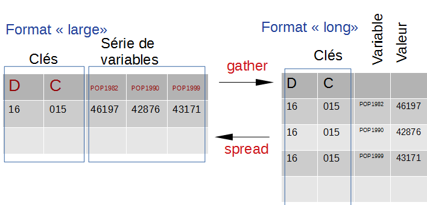

## Exemples

### Du format large au format long : `gather`

La fonction `gather` prend deux arguments obligatoires, successivement : le nom de la colonne qui contiendra les coordonnées horizontales (les noms de colonnes originaux) puis le nom de la colonne qui recevra les valeurs. Ce qui vient après est la spécification des colonnes d’interêt qu’on peut fournir au moyen des différentes syntaxes autorisées pour la sélection de colonnes (`select` de **dplyr**). Toutes les variables qui ne seront pas citées seront conservées dans le résultat.

```r
# Toutes les colonnes sauf "Commune"
pops0 %>% gather("Date","valeur",-Commune) -> pops1
pops1
```

```
##    Commune Date valeur
## 1    16015 2015  42081
## 2    17300 2015  75404
## 3    79191 2015  58952
## 4    86194 2015  87918
## 5    16015 2010  41613
## 6    17300 2010  75170
## 7    79191 2010  57325
## 8    86194 2010  87697
## 9    16015 2006  42096
## 10   17300 2006  77196
## 11   79191 2006  58066
## 12   86194 2006  88776
```

Les appels à `gather`qui suivent donnent le même résultat. Plutôt que d’afficher celui ci on le passe à la fonction `identical` qui teste si deux objets R ont le même contenu.

```r
# Toutes les colonnes dont le nom commence par "20"
pops0 %>% gather("Date","valeur",matches("^20")) %>% identical(pops1)
```

```
## [1] TRUE
```

```r
# Les trois colonnes "2015", "2010" et "2006"
pops0 %>% gather("Date","valeur","2015","2010","2006") %>% identical(pops1)
```

```
## [1] TRUE
```

```r
pops0 %>% gather("Date","valeur",c("2015","2010","2006")) %>% identical(pops1)
```

```
## [1] TRUE
```

```r
# Les 2ème à 4ème colonnes (pas très explicite, donc déconseillé)
pops0 %>% gather("Date","valeur",2:4) %>% identical(pops1)
```

```
## [1] TRUE
```

### Du format long au format large : `spread`

La fonction `spread` prend deux arguments obligatoires : le nom de la colonne qui contient les noms des futures colonnes puis le nom de la colonne qui en contient les valeurs. Les autres colonnes se retrouveront comme identifiants des futures lignes.

```r
pops1 %>% spread("Date","valeur")
```

```
##   Commune  2006  2010  2015
## 1   16015 42096 41613 42081
## 2   17300 77196 75170 75404
## 3   79191 58066 57325 58952
## 4   86194 88776 87697 87918
```

On ne peut pas avoir plusieurs fois le même couple (nom de future colonne, identifiant de la future ligne) :

```r
pops1 %>%
  add_row(Commune="16015", Date="2006", valeur=0) %>%
  spread("Date","valeur")
```

```
## Duplicate identifiers for rows (9, 13)
```

### Une transposition totale

Pour faire une transposition classique, il suffit de permutter le rôle des lignes et des colonnes, ce qui est très simple lorsqu’on a mis la table en format “long”" où identifiant de ligne et de colonne jouent le même rôle :

```r
pops0 %>% gather("Date","valeur",-Commune) %>% spread("Commune","valeur")
```

```
##   Date 16015 17300 79191 86194
## 1 2006 42096 77196 58066 88776
## 2 2010 41613 75170 57325 87697
## 3 2015 42081 75404 58952 87918
```

### Faire des statistiques sur des données présentées en ligne

Les valeurs minimales et maximales des populations (les minimas et maximas d’un ensemble de colonnes) :

```r
pops0 %>%
  gather("Date","valeur",-Commune) %>%
  group_by(Commune) %>%
  summarise(min=min(valeur),max=max(valeur))
```

```
## # A tibble: 4 x 3
##   Commune   min   max
##   <chr>   <dbl> <dbl>
## 1 16015   41613 42096
## 2 17300   75170 77196
## 3 79191   57325 58952
## 4 86194   87697 88776
```

L’année où la population est maximale (le nom de la colonne où la donnée est maximale) :

```r
pops0 %>%
  gather("Date","valeur",-Commune) %>%
  group_by(Commune) %>%
  filter(valeur==max(valeur)) %>%
  ungroup %>%
  mutate(k="annee_max") %>%
  spread("k","Date")
```

```
## # A tibble: 4 x 3
##   Commune valeur annee_max
##   <chr>    <dbl> <chr>
## 1 16015    42096 2006
## 2 17300    77196 2006
## 3 79191    58952 2015
## 4 86194    88776 2006
```

## Solutions viables non retenues

### R de base

En R de base, la transposition totale peut se faire avec la fonction `t` qui est en fait une fonction travaillant sur des matrices et produisant une matrice. Il faudra donc faire une conversion en data.frame et également introduire des noms pour les nouvelles colonnes. Au final la manipulation est plus compliquée qu’avec le package **tidyr**.  
Les opérations de mise en format long ou large sont réalisables avec la fonction `reshape` qui regroupe les fonctionnalités de `gather`et `spread`et qui a été plus spécifiquement conçue pour la transformation d’ensembles de séries temporelles. Cette fonction n’appartient pas au tidyverse et offre des modes de selection des colonnes bien plus restrictives.

### Le package **reshape2**

Le package **reshape2** offre deux fonctions `melt`et `cast` qui permettent les mêmes transformations que `gather`et `spread` plus des possibilités d’agrégation pour la seconde fonction. A la différence des fonctions de **tidyr** qui se mélangent bien avec les fonctions de **dplyr**, les fonctions de **reshape2** viennent du monde de **data.table** qui a sa propre logique et sa propre syntaxe.

## Solutions à ne pas utiliser

Aucune.

## Niveau d’intégration à l’USSR

### Développements préconisés

Aucun

### Points de vigilance

Aucun.

## Intégration au dispositif de formation

La présentation des outils préconisés forme une séquence de la formation “prise en main rapide de données sous R”.